# Homework-1

```r
#necessary libraries
library(dplyr)
library(Amelia)
library(vcd)
library(lubridate)
library(data.table)
library(ggplot2)
```

#English Premier League is selected

```r
matches = read.table('matches.csv', header=TRUE, sep=',')
select_epl=filter(matches, league_id=="148")
select_epl=select_epl %>% mutate(final =match_hometeam_score-match_awayteam_score)
select_epl$finalstatus = ifelse(select_epl$match_awayteam_score==select_epl$match_hometeam_score,"draw",ifelse(select_epl$match_awayteam_score>select_epl$match_hometeam_score,"away","home"))
```

#missing control for selected variables

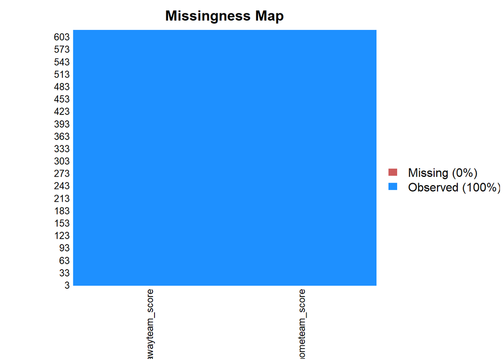

```r
slc<- select(select_epl,match_hometeam_score,match_awayteam_score)
missmap(slc)
```

Home Score histogram&fitting line

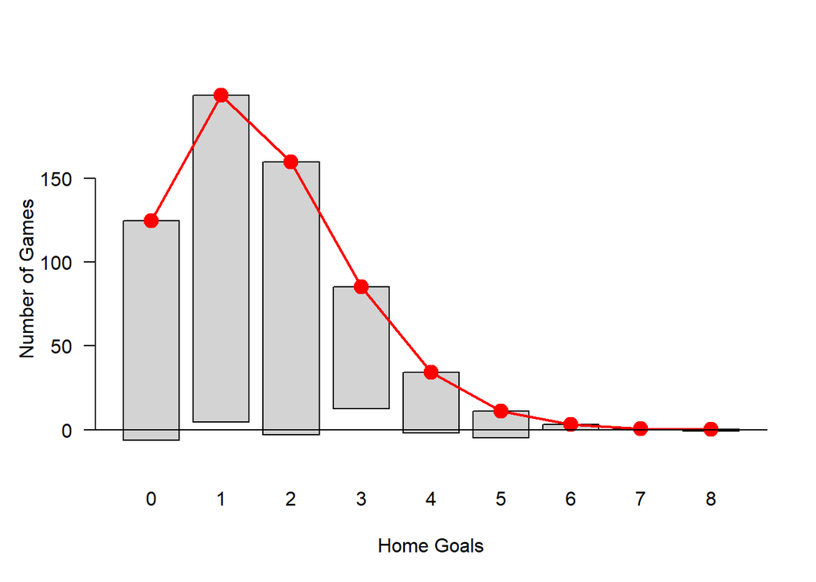

```r
gf <- goodfit(select_epl$match_hometeam_score, "poisson")
plot(gf, type = "h", scale = "raw", xlab="Home Goals",ylab="Number of Games")
```

Away Score histogram&fitting line

Both Home and Away Score are poisson distributed as seen from histograms

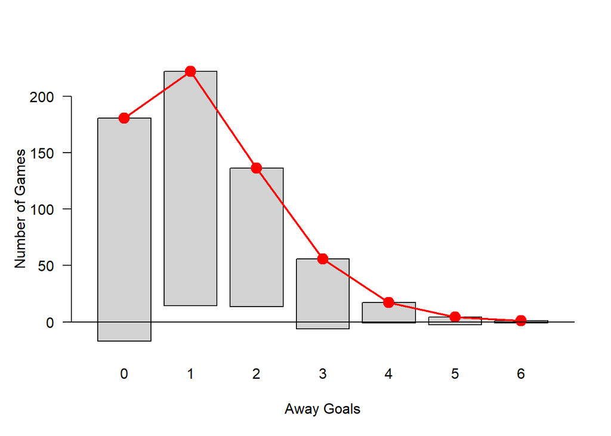

```r
gf2 <- goodfit(select_epl$match_awayteam_score, "poisson")
plot(gf2, type = "h", scale = "raw", xlab="Away Goals",ylab="Number of Games")
```

Home-Away score is calculated and histogram plotted. It fits skellam distribution. (The distribution of the difference between two Poisson Distribution is fitted to Skellam Distribution)

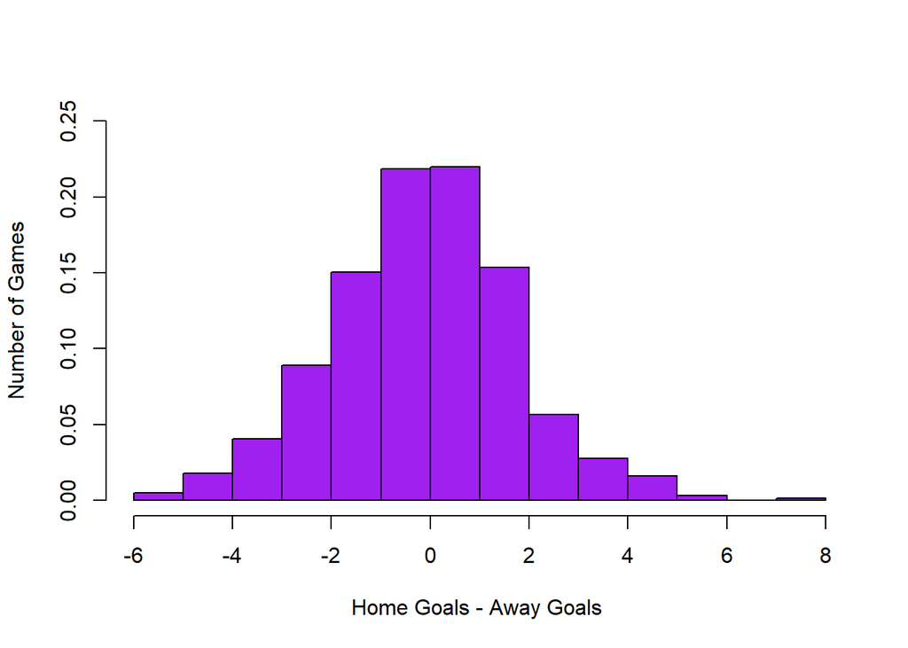

```r
my_data <- as_tibble(select_epl)
my_data=my_data %>% mutate(diff =match_hometeam_score-match_awayteam_score)

h_a<-hist(my_data$diff, prob=TRUE, ylim = c(0, .25),col="purple", xlab="Home Goals - Away Goals ",
           ylab="Number of Games", main=" ")
```

quest 2 – matches and bets data are joined

```r
bets = read.table('bets.csv', header=TRUE, sep=',')

slc_match<- dplyr::select(select_epl,match_id,epoch, match_status,match_hometeam_score,match_awayteam_score,league_id,finalstatus)
leftJoin <- left_join(slc_match,bets,by="match_id")
```

Some ids(eg id 13331,13329) not in bets data but available in matches data – so inner join is done.

```r
innerJoin <- inner_join(slc_match,bets,by="match_id")
m1=filter(select_epl, match_id=="13329") #control

innercal=mutate(innerJoin,prob=1/value)
innercal=mutate(innercal,epoch_trn=as_datetime(innerJoin$epoch))
innercal=mutate(innercal,oddepoch_trn=as_datetime(innerJoin$odd_epoch))
```

Bookmakers:Marathonbet,Dotabet,Unibet,Titanbet & Variable:odd_1-odd_2-odd_x are selected

```r
innercalbm=innercal%>%filter(odd_bookmakers %in% c("Marathonbet", "Dotabet","Unibet","Titanbet") & variable %in% c("odd_1", "odd_x","odd_2") )
```

in some matches (eg match_id = 162714) the odd_1, odd_2, odd_x fields were twice, due to the odd_epoch field.so max date from the odd_epoch field was chosen.

```r
innercalbm_unq=innercalbm %>% group_by(match_id,odd_bookmakers, variable) %>%summarise(max = max(oddepoch_trn))
innercalbm_unqq <- left_join(innercalbm_unq,innercalbm,by = c("match_id" = "match_id","odd_bookmakers"="odd_bookmakers","variable"="variable","max" = "oddepoch_trn"))
```

normalization step

```r
dtot=innercalbm_unqq %>%
  group_by(match_id,odd_bookmakers) %>%
  summarise(totalprb = sum(prob))

innercalbm_unqq <- left_join(innercalbm_unqq,dtot,by = c("match_id" = "match_id","odd_bookmakers"="odd_bookmakers"))
innercalbm_unqq=innercalbm_unqq %>% mutate(normprob =prob/totalprb)
```

Marathonbet is selected

```r
innercalbm_mar=filter(innercalbm_unqq,odd_bookmakers=="Marathonbet")
x=setDF(innercalbm_mar)
basic_summ_t2 = dcast(x, match_id + finalstatus ~ variable , value.var = "normprob")
basic_summ_t2=basic_summ_t2 %>% mutate(diff =odd_1-odd_2)
summary(basic_summ_t2$diff)
```

```
##    Min. 1st Qu.  Median    Mean 3rd Qu.    Max.
## -0.7853 -0.1139  0.1460  0.1433  0.4388  0.8598
```

for actual prob calculation

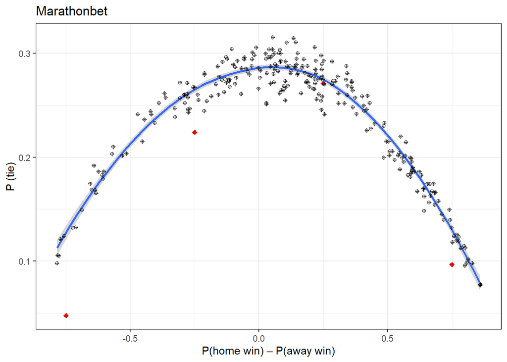

```r
basic_summ_t2$interval = ifelse(-1<basic_summ_t2$diff & basic_summ_t2$diff< -0.5,-0.75,ifelse(-0.5<basic_summ_t2$diff & basic_summ_t2$diff<0,-0.25,ifelse(0<basic_summ_t2$diff & basic_summ_t2$diff<0.5,0.25,0.75)))
total=basic_summ_t2 %>%group_by(interval) %>% summarize(n=n())
draws=basic_summ_t2 %>% filter(finalstatus == "draw")
totaldraw=draws %>%group_by(interval) %>% summarize(drawcnt=n())
ttl <- left_join(total,totaldraw,by="interval")
ttl= ttl%>%mutate(sampleprb=drawcnt/n)
ggplot(basic_summ_t2, aes(x = diff, y = odd_x)) +theme_bw() +geom_smooth()+ggtitle("Marathonbet")+xlab("P(home win) – P(away win)") + ylab("P (tie)")+geom_point(data=ttl,aes(x=interval,y=sampleprb),shape=23, fill="red", color="darkred")+geom_point(data = basic_summ_t2, aes(x = diff, y = odd_x),shape=10,fill="white", color="black")
```

Dotabet is selected

```r
innercalbm_dot=filter(innercalbm_unqq,odd_bookmakers=="Dotabet")
xd=setDF(innercalbm_dot)
basic_summ_dot = dcast(xd, match_id + finalstatus ~ variable , value.var = "prob")
basic_summ_dot=basic_summ_dot %>% mutate(diff =odd_1-odd_2)
summary(basic_summ_dot$diff)
```

```
##     Min.  1st Qu.   Median     Mean  3rd Qu.     Max.
## -0.87208 -0.24963  0.13824  0.07151  0.32374  0.92087
```

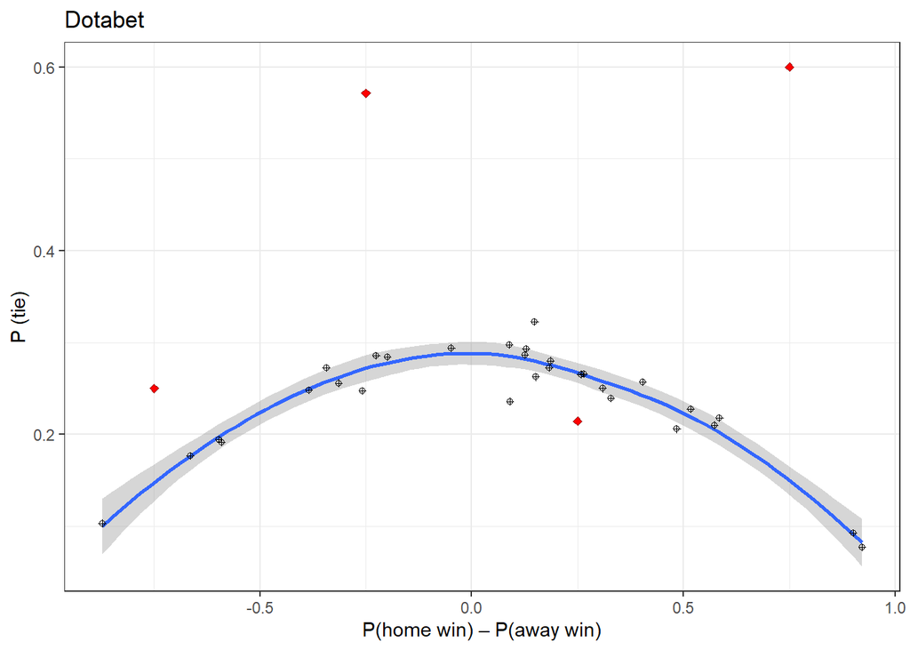

```r
#for actual prob calculation
basic_summ_dot$interval = ifelse(-1<basic_summ_dot$diff & basic_summ_dot$diff< -0.5,-0.75,ifelse(-0.5<basic_summ_dot$diff & basic_summ_dot$diff<0,-0.25,ifelse(0<basic_summ_dot$diff & basic_summ_dot$diff<0.5,0.25,0.75)))
totaldot=basic_summ_dot %>%group_by(interval) %>% summarize(n=n())
drawsdot=basic_summ_dot %>% filter(finalstatus == "draw")
totaldrawdot=drawsdot %>%group_by(interval) %>% summarize(drawcnt=n())
ttldot<- left_join(totaldot,totaldrawdot,by="interval")
ttldot= ttldot%>%mutate(sampleprb=drawcnt/n)
ggplot(basic_summ_dot, aes(x = diff, y = odd_x)) +theme_bw() +geom_smooth()+ggtitle("Dotabet")+xlab("P(home win) – P(away win)") + ylab("P (tie)")+geom_point(data=ttldot,aes(x=interval,y=sampleprb),shape=23, fill="red", color="darkred")+geom_point(data = basic_summ_dot, aes(x = diff, y = odd_x),shape=10,fill="white", color="black")
```

Unibet is selected

```r
innercalbm_uni=filter(innercalbm_unqq,odd_bookmakers=="Unibet")
xu=setDF(innercalbm_uni)
basic_summ_uni = dcast(xu, match_id + finalstatus ~ variable , value.var = "prob")
basic_summ_uni=basic_summ_uni %>% mutate(diff =odd_1-odd_2)
summary(basic_summ_uni$diff)
```

```
##    Min. 1st Qu.  Median    Mean 3rd Qu.    Max.
## -0.8296 -0.1063  0.1587  0.1542  0.5008  0.8875
```

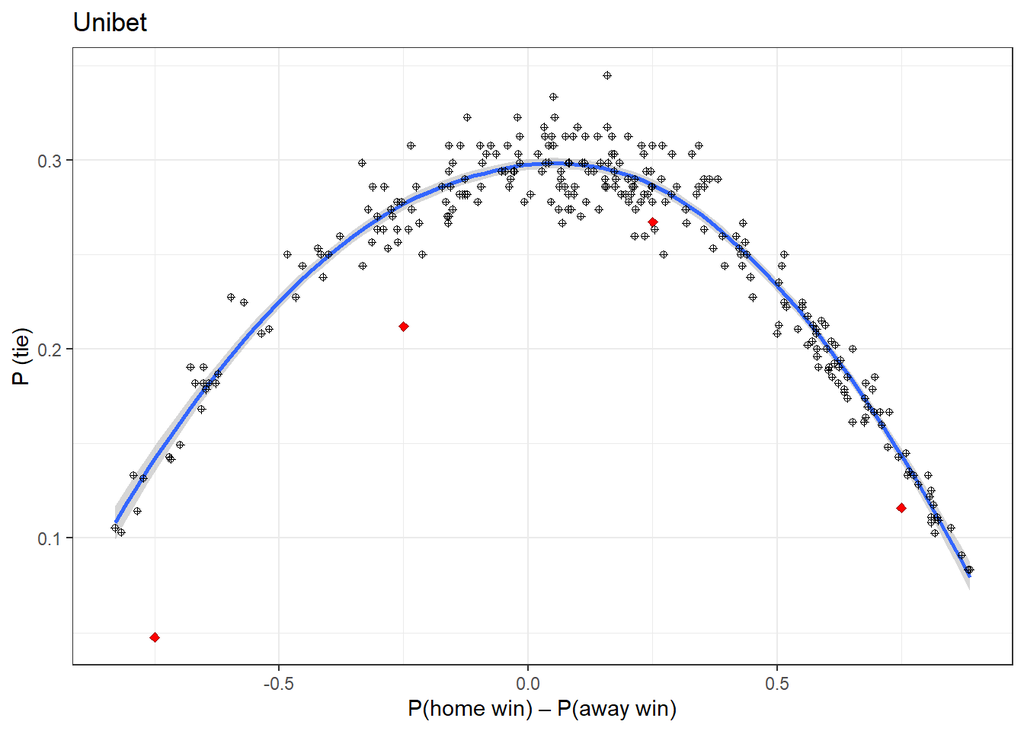

```r
#for actual prob
basic_summ_uni$interval = ifelse(-1<basic_summ_uni$diff & basic_summ_uni$diff< -0.5,-0.75,ifelse(-0.5<basic_summ_uni$diff & basic_summ_uni$diff<0,-0.25,ifelse(0<basic_summ_uni$diff & basic_summ_uni$diff<0.5,0.25,0.75)))
totaluni=basic_summ_uni %>%group_by(interval) %>% summarize(n=n())
drawsuni=basic_summ_uni %>% filter(finalstatus == "draw")
totaldrawuni=drawsuni %>%group_by(interval) %>% summarize(drawcnt=n())
ttluni<- left_join(totaluni,totaldrawuni,by="interval")
ttluni= ttluni%>%mutate(sampleprb=drawcnt/n)
ggplot(basic_summ_uni, aes(x = diff, y = odd_x)) +theme_bw() +geom_smooth()+ggtitle("Unibet")+xlab("P(home win) – P(away win)") + ylab("P (tie)")+
  geom_point(data=ttluni,aes(x=interval,y=sampleprb),shape=23, fill="red", color="darkred")+geom_point(data = basic_summ_uni, aes(x = diff, y = odd_x),shape=10,fill="white", color="black")
```

Titanbet is selected

```r
innercalbm_titan=filter(innercalbm_unqq,odd_bookmakers=="Titanbet")
xt=setDF(innercalbm_titan)
basic_summ_titan= dcast(xt, match_id +finalstatus ~ variable , value.var = "prob")
basic_summ_titan=basic_summ_titan %>% mutate(diff =odd_1-odd_2)
summary(basic_summ_titan$diff)
```

```
##    Min. 1st Qu.  Median    Mean 3rd Qu.    Max.
## -0.8533 -0.1219  0.1515  0.1499  0.4551  0.9023
```

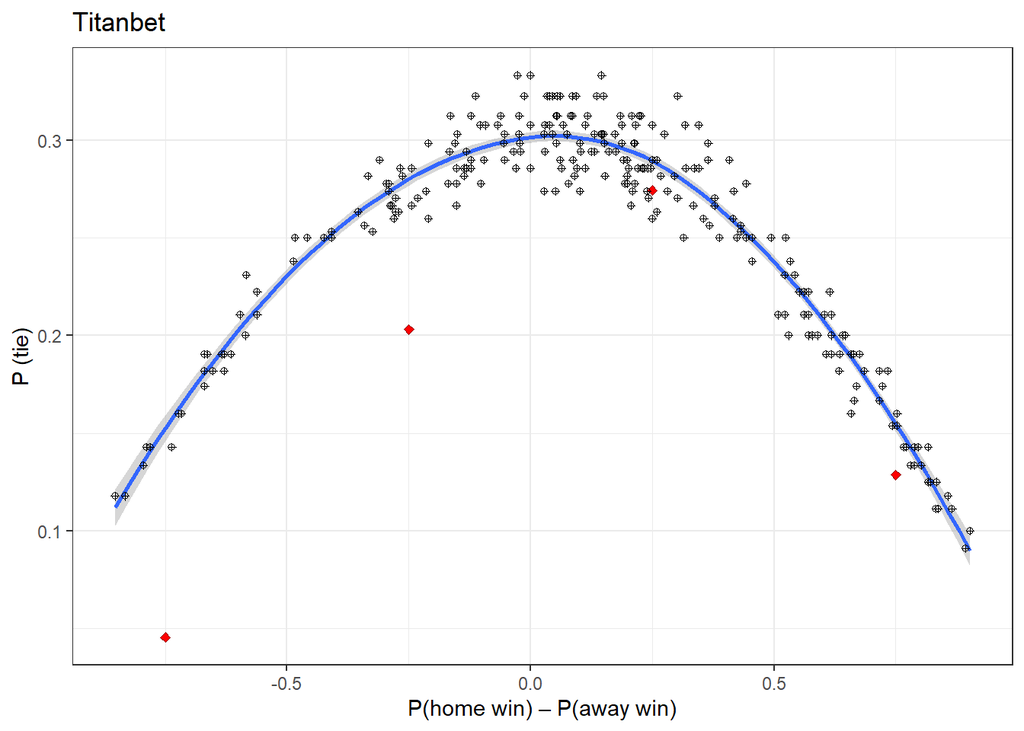

```r
#for actual prob
basic_summ_titan$interval = ifelse(-1<basic_summ_titan$diff & basic_summ_titan$diff< -0.5,-0.75,ifelse(-0.5<basic_summ_titan$diff & basic_summ_titan$diff<0,-0.25,ifelse(0<basic_summ_titan$diff & basic_summ_titan$diff<0.5,0.25,0.75)))
totaltitan=basic_summ_titan %>%group_by(interval) %>% summarize(n=n())
drawstitan=basic_summ_titan %>% filter(finalstatus == "draw")
totaldrawtitan=drawstitan %>%group_by(interval) %>% summarize(drawcnt=n())
ttltitan<- left_join(totaltitan,totaldrawtitan,by="interval")
ttltitan= ttltitan%>%mutate(sampleprb=drawcnt/n)
ggplot(basic_summ_titan, aes(x = diff, y = odd_x)) +theme_bw() +geom_smooth()+ggtitle("Titanbet")+xlab("P(home win) – P(away win)") + ylab("P (tie)")+
  geom_point(data=ttltitan,aes(x=interval,y=sampleprb),shape=23, fill="red", color="darkred")+geom_point(data = basic_summ_titan, aes(x = diff, y = odd_x),shape=10,fill="white", color="black")
```

Sample prob>Bookmakers Prob–>make money. The trend line for odds was not well matched with the actual results of the matches.

quest 3 data prep

```r
goals = read.table('goals.csv', header=TRUE, sep=',')
booking = read.table('booking.csv', header=TRUE, sep=',')

#first case --- 90+ goals
#matches were selected which are change the result of match after 90+ minutes
goals$tm=base::substr(goals$time, 1, 2)
goals$tm <- as.numeric(goals$tm)

goals$homesc=base::substr(goals$score, 1, 1)
goals$homesc <- as.numeric(goals$homesc)

goals$awaysc=base::substr(goals$score, 5, 5)
goals$awaysc <- as.numeric(goals$awaysc)

selc1case=goals%>%filter(tm==90)
selc1case=selc1case %>% mutate(diffsc =abs(homesc-awaysc))

selc1case$case1=ifelse(selc1case$diffsc==0 | selc1case$diffsc==1,1,0)

selcasedel=filter(selc1case, case1==1)

delcase1=anti_join(innercalbm_unqq, selcasedel, by = "match_id")
```

165 observation is deleted for the first case

For Marathonbet:

```r
scnd_mar=filter(delcase1,odd_bookmakers=="Marathonbet")
xm2=setDF(scnd_mar)
basic_summ_mar2 = dcast(xm2, match_id+finalstatus ~ variable , value.var = "prob")
basic_summ_mar2=basic_summ_mar2 %>% mutate(diff =odd_1-odd_2)
summary(basic_summ_mar2$diff)
```

```
##    Min. 1st Qu.  Median    Mean 3rd Qu.    Max.
## -0.8024 -0.1223  0.1407  0.1366  0.4314  0.8852
```

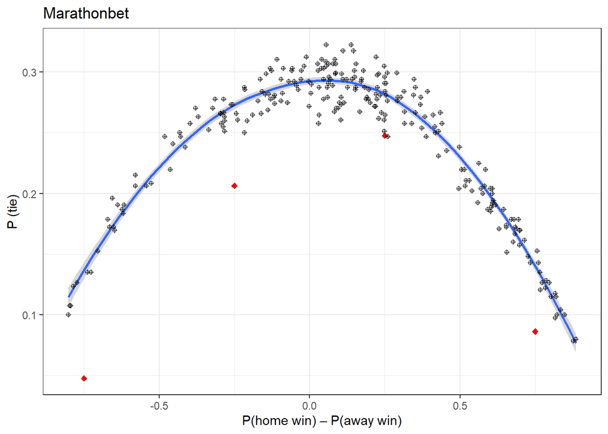

```r
#for actual prob
basic_summ_mar2$interval = ifelse(-1<basic_summ_mar2$diff & basic_summ_mar2$diff< -0.5,-0.75,ifelse(-0.5<basic_summ_mar2$diff & basic_summ_mar2$diff<0,-0.25,ifelse(0<basic_summ_mar2$diff & basic_summ_mar2$diff<0.5,0.25,0.75)))
totalmar2=basic_summ_mar2 %>%group_by(interval) %>% summarize(n=n())
drawsmar2=basic_summ_mar2 %>% filter(finalstatus == "draw")
totaldrawmar2=drawsmar2 %>%group_by(interval) %>% summarize(drawcnt=n())
ttlmar2 <- left_join(totalmar2,totaldrawmar2,by="interval")
ttlmar2= ttlmar2%>%mutate(sampleprb=drawcnt/n)
ggplot(basic_summ_mar2, aes(x = diff, y = odd_x)) +theme_bw() +geom_smooth()+ggtitle("Marathonbet")+xlab("P(home win) – P(away win)") + ylab("P (tie)")+
  geom_point(data=ttlmar2,aes(x=interval,y=sampleprb),shape=23, fill="red", color="darkred")+geom_point(data = basic_summ_mar2, aes(x = diff, y = odd_x),shape=10,fill="white", color="black")
```

For Dotabet

```r
scnd_dot=filter(delcase1,odd_bookmakers=="Dotabet")
xd2=setDF(scnd_dot)
basic_summ_dot2 = dcast(xd2, match_id + finalstatus ~ variable , value.var = "prob")
basic_summ_dot2=basic_summ_dot2 %>% mutate(diff =odd_1-odd_2)
summary(basic_summ_dot2$diff)
```

```
##    Min. 1st Qu.  Median    Mean 3rd Qu.    Max.
## -0.8721 -0.2187  0.1500  0.1074  0.3846  0.9209
```

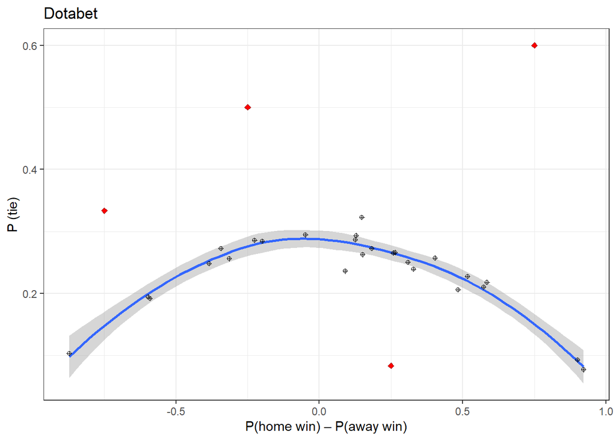

```r
#for actual prob
basic_summ_dot2$interval = ifelse(-1<basic_summ_dot2$diff & basic_summ_dot2$diff< -0.5,-0.75,ifelse(-0.5<basic_summ_dot2$diff & basic_summ_dot2$diff<0,-0.25,ifelse(0<basic_summ_dot2$diff & basic_summ_dot2$diff<0.5,0.25,0.75)))
totaldot2=basic_summ_dot2 %>%group_by(interval) %>% summarize(n=n())
drawsdot2=basic_summ_dot2 %>% filter(finalstatus == "draw")
totaldrawdot2=drawsdot2 %>%group_by(interval) %>% summarize(drawcnt=n())
ttldot2<- left_join(totaldot2,totaldrawdot2,by="interval")
ttldot2= ttldot2%>%mutate(sampleprb=drawcnt/n)
library(ggplot2)
ggplot(basic_summ_dot2, aes(x = diff, y = odd_x)) +theme_bw() +geom_smooth()+ggtitle("Dotabet")+xlab("P(home win) – P(away win)") + ylab("P (tie)")+
  geom_point(data=ttldot2,aes(x=interval,y=sampleprb),shape=23, fill="red", color="darkred")+geom_point(data = basic_summ_dot2, aes(x = diff, y = odd_x),shape=10,fill="white", color="black")
```

For Unibet

```r
scnd_uni=filter(delcase1,odd_bookmakers=="Unibet")
xu2=setDF(scnd_uni)
basic_summ_uni2 = dcast(xu2, match_id + finalstatus ~ variable , value.var = "prob")
basic_summ_uni2=basic_summ_uni2 %>% mutate(diff =odd_1-odd_2)
summary(basic_summ_uni2$diff)
```

```
##    Min. 1st Qu.  Median    Mean 3rd Qu.    Max.
## -0.8296 -0.1270  0.1546  0.1450  0.4452  0.8875
```

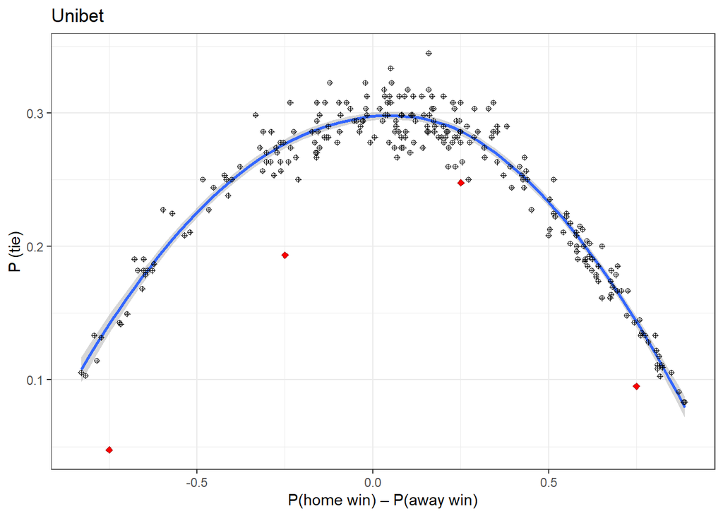

```r
#for actual prob
basic_summ_uni2$interval = ifelse(-1<basic_summ_uni2$diff & basic_summ_uni2$diff< -0.5,-0.75,ifelse(-0.5<basic_summ_uni2$diff & basic_summ_uni2$diff<0,-0.25,ifelse(0<basic_summ_uni2$diff & basic_summ_uni2$diff<0.5,0.25,0.75)))
totaluni2=basic_summ_uni2 %>%group_by(interval) %>% summarize(n=n())
drawsuni2=basic_summ_uni2 %>% filter(finalstatus == "draw")
totaldrawuni2=drawsuni2 %>%group_by(interval) %>% summarize(drawcnt=n())
ttluni2<- left_join(totaluni2,totaldrawuni2,by="interval")
ttluni2= ttluni2%>%mutate(sampleprb=drawcnt/n)
library(ggplot2)
ggplot(basic_summ_uni2, aes(x = diff, y = odd_x)) +theme_bw() +geom_smooth()+ggtitle("Unibet")+xlab("P(home win) – P(away win)") + ylab("P (tie)")+
  geom_point(data=ttluni2,aes(x=interval,y=sampleprb),shape=23, fill="red", color="darkred")+geom_point(data = basic_summ_uni2, aes(x = diff, y = odd_x),shape=10,fill="white", color="black")
```

For Titanbet

```r
scnd_titan=filter(delcase1,odd_bookmakers=="Titanbet")
xt2=setDF(scnd_titan)
basic_summ_titan2= dcast(xt2, match_id +finalstatus ~ variable , value.var = "prob")
basic_summ_titan2=basic_summ_titan2 %>% mutate(diff =odd_1-odd_2)
summary(basic_summ_titan2$diff)
```

```
##    Min. 1st Qu.  Median    Mean 3rd Qu.    Max.
## -0.8533 -0.1249  0.1464  0.1402  0.4432  0.9023
```

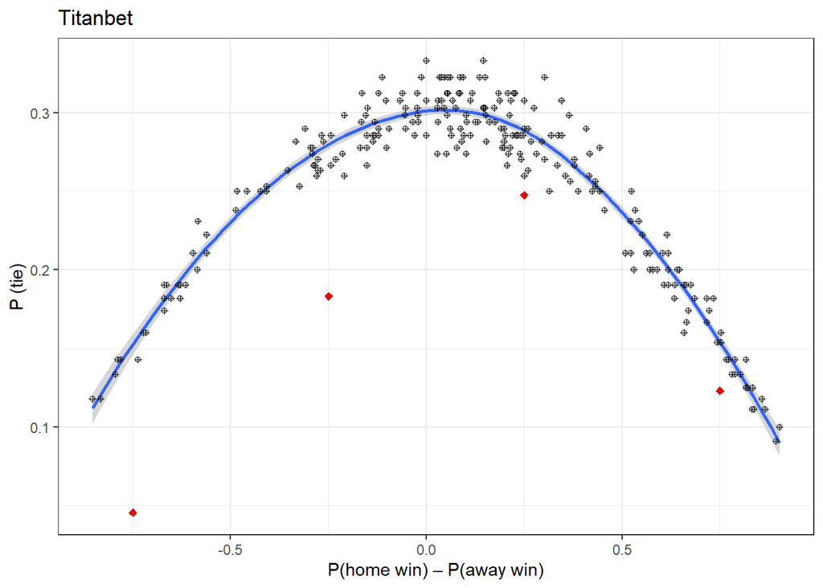

```r
#for actual prob
basic_summ_titan2$interval = ifelse(-1<basic_summ_titan2$diff & basic_summ_titan2$diff< -0.5,-0.75,ifelse(-0.5<basic_summ_titan2$diff & basic_summ_titan2$diff<0,-0.25,ifelse(0<basic_summ_titan2$diff & basic_summ_titan2$diff<0.5,0.25,0.75)))
totaltitan2=basic_summ_titan2 %>%group_by(interval) %>% summarize(n=n())
drawstitan2=basic_summ_titan2 %>% filter(finalstatus == "draw")
totaldrawtitan2=drawstitan2 %>%group_by(interval) %>% summarize(drawcnt=n())
ttltitan2<- left_join(totaltitan2,totaldrawtitan2,by="interval")
ttltitan2= ttltitan2%>%mutate(sampleprb=drawcnt/n)
ggplot(basic_summ_titan2, aes(x = diff, y = odd_x)) +theme_bw() +geom_smooth()+ggtitle("Titanbet")+xlab("P(home win) – P(away win)") + ylab("P (tie)")+
  geom_point(data=ttltitan2,aes(x=interval,y=sampleprb),shape=23, fill="red", color="darkred")+geom_point(data = basic_summ_titan2, aes(x = diff, y = odd_x),shape=10,fill="white", color="black")
```

second case — A red card in the first 15 minutes

```r
booking$xxs=base::substr(booking$time, 1, 2)
booking$xxs <- as.numeric(booking$xxs)
selc2case=booking%>%filter(xxs<16 & card=="red card")
delcase2=anti_join(innercalbm_unqq, selc2case, by = "match_id")
```

18 observation is deleted for the second case

For Marathonbet:

```r
thrd_mar=filter(delcase2,odd_bookmakers=="Marathonbet")
xm3=setDF(thrd_mar)
basic_summ_mar3 = dcast(xm3, match_id+finalstatus ~ variable , value.var = "prob")
basic_summ_mar3=basic_summ_mar3 %>% mutate(diff =odd_1-odd_2)
summary(basic_summ_mar3$diff)
```

```
##    Min. 1st Qu.  Median    Mean 3rd Qu.    Max.
## -0.8024 -0.1145  0.1508  0.1488  0.4532  0.8852
```

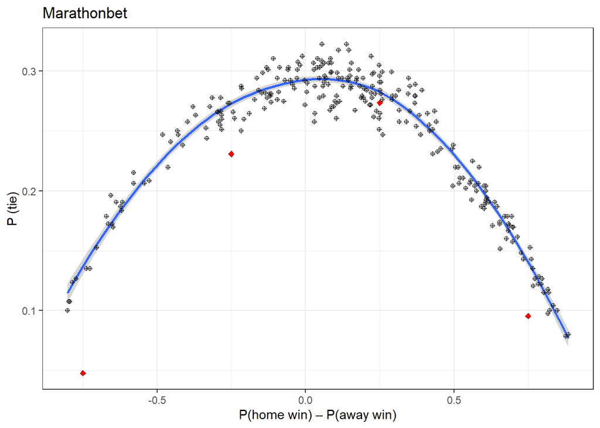

```r
#for actual prob
basic_summ_mar3$interval = ifelse(-1<basic_summ_mar3$diff & basic_summ_mar3$diff< -0.5,-0.75,ifelse(-0.5<basic_summ_mar3$diff & basic_summ_mar3$diff<0,-0.25,ifelse(0<basic_summ_mar3$diff & basic_summ_mar3$diff<0.5,0.25,0.75)))
totalmar3=basic_summ_mar3 %>%group_by(interval) %>% summarize(n=n())
drawsmar3=basic_summ_mar3 %>% filter(finalstatus == "draw")
totaldrawmar3=drawsmar3 %>%group_by(interval) %>% summarize(drawcnt=n())
ttlmar3 <- left_join(totalmar3,totaldrawmar3,by="interval")
ttlmar3= ttlmar3%>%mutate(sampleprb=drawcnt/n)
ggplot(basic_summ_mar3, aes(x = diff, y = odd_x)) +theme_bw() +geom_smooth()+ggtitle("Marathonbet")+xlab("P(home win) – P(away win)") + ylab("P (tie)")+
  geom_point(data=ttlmar3,aes(x=interval,y=sampleprb),shape=23, fill="red", color="darkred")+geom_point(data = basic_summ_mar3, aes(x = diff, y = odd_x),shape=10,fill="white", color="black")
```

For Dotabet

```r
thrd_dot=filter(delcase2,odd_bookmakers=="Dotabet")
xd3=setDF(thrd_dot)
basic_summ_dot3 = dcast(xd3, match_id + finalstatus ~ variable , value.var = "prob")
basic_summ_dot3=basic_summ_dot3 %>% mutate(diff =odd_1-odd_2)
summary(basic_summ_dot3$diff)
```

```
##     Min.  1st Qu.   Median     Mean  3rd Qu.     Max.
## -0.87208 -0.24963  0.13824  0.07151  0.32374  0.92087
```

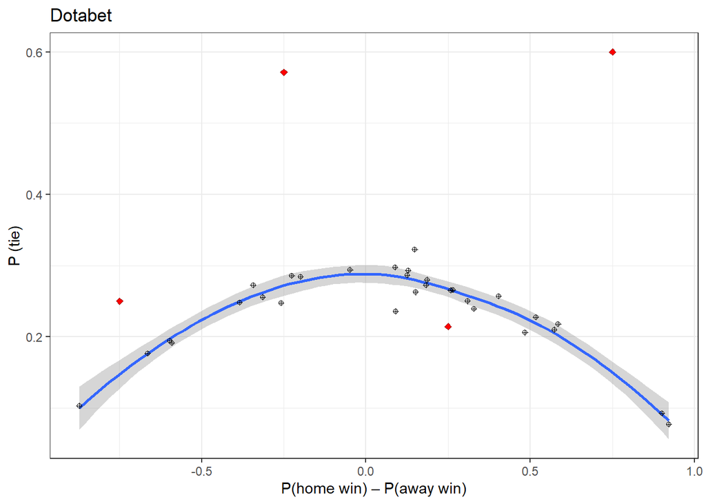

```r
#for actual prob
basic_summ_dot3$interval = ifelse(-1<basic_summ_dot3$diff & basic_summ_dot3$diff< -0.5,-0.75,ifelse(-0.5<basic_summ_dot3$diff & basic_summ_dot3$diff<0,-0.25,ifelse(0<basic_summ_dot3$diff & basic_summ_dot3$diff<0.5,0.25,0.75)))
totaldot3=basic_summ_dot3 %>%group_by(interval) %>% summarize(n=n())
drawsdot3=basic_summ_dot3 %>% filter(finalstatus == "draw")
totaldrawdot3=drawsdot3 %>%group_by(interval) %>% summarize(drawcnt=n())
ttldot3<- left_join(totaldot3,totaldrawdot3,by="interval")
ttldot3= ttldot3%>%mutate(sampleprb=drawcnt/n)
ggplot(basic_summ_dot3, aes(x = diff, y = odd_x)) +theme_bw() +geom_smooth()+ggtitle("Dotabet")+xlab("P(home win) – P(away win)") + ylab("P (tie)")+
  geom_point(data=ttldot3,aes(x=interval,y=sampleprb),shape=23, fill="red", color="darkred")+geom_point(data = basic_summ_dot3, aes(x = diff, y = odd_x),shape=10,fill="white", color="black")
```

For Unibet

```r
thrd_uni=filter(delcase2,odd_bookmakers=="Unibet")
xu3=setDF(thrd_uni)
basic_summ_uni3 = dcast(xu3, match_id + finalstatus ~ variable , value.var = "prob")
basic_summ_uni3=basic_summ_uni3 %>% mutate(diff =odd_1-odd_2)
summary(basic_summ_uni3$diff)
```

```
##    Min. 1st Qu.  Median    Mean 3rd Qu.    Max.
## -0.8296 -0.0998  0.1596  0.1563  0.5025  0.8875
```

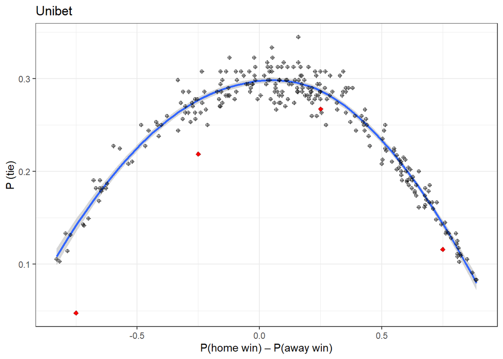

```r
#for actual prob
basic_summ_uni3$interval = ifelse(-1<basic_summ_uni3$diff & basic_summ_uni3$diff< -0.5,-0.75,ifelse(-0.5<basic_summ_uni3$diff & basic_summ_uni3$diff<0,-0.25,ifelse(0<basic_summ_uni3$diff & basic_summ_uni3$diff<0.5,0.25,0.75)))
totaluni3=basic_summ_uni3 %>%group_by(interval) %>% summarize(n=n())
drawsuni3=basic_summ_uni3 %>% filter(finalstatus == "draw")
totaldrawuni3=drawsuni3 %>%group_by(interval) %>% summarize(drawcnt=n())
ttluni3<- left_join(totaluni3,totaldrawuni3,by="interval")
ttluni3= ttluni3%>%mutate(sampleprb=drawcnt/n)
ggplot(basic_summ_uni3, aes(x = diff, y = odd_x)) +theme_bw() +geom_smooth()+ggtitle("Unibet")+xlab("P(home win) – P(away win)") + ylab("P (tie)")+
  geom_point(data=ttluni3,aes(x=interval,y=sampleprb),shape=23, fill="red", color="darkred")+geom_point(data = basic_summ_uni3, aes(x = diff, y = odd_x),shape=10,fill="white", color="black")
```

For Titanbet

```r
thrd_titan=filter(delcase2,odd_bookmakers=="Titanbet")
xt3=setDF(thrd_titan)
basic_summ_titan3= dcast(xt3, match_id +finalstatus ~ variable , value.var = "prob")
basic_summ_titan3=basic_summ_titan3 %>% mutate(diff =odd_1-odd_2)
summary(basic_summ_titan3$diff)
```

```
##    Min. 1st Qu.  Median    Mean 3rd Qu.    Max.
## -0.8533 -0.1174  0.1526  0.1520  0.4744  0.9023
```

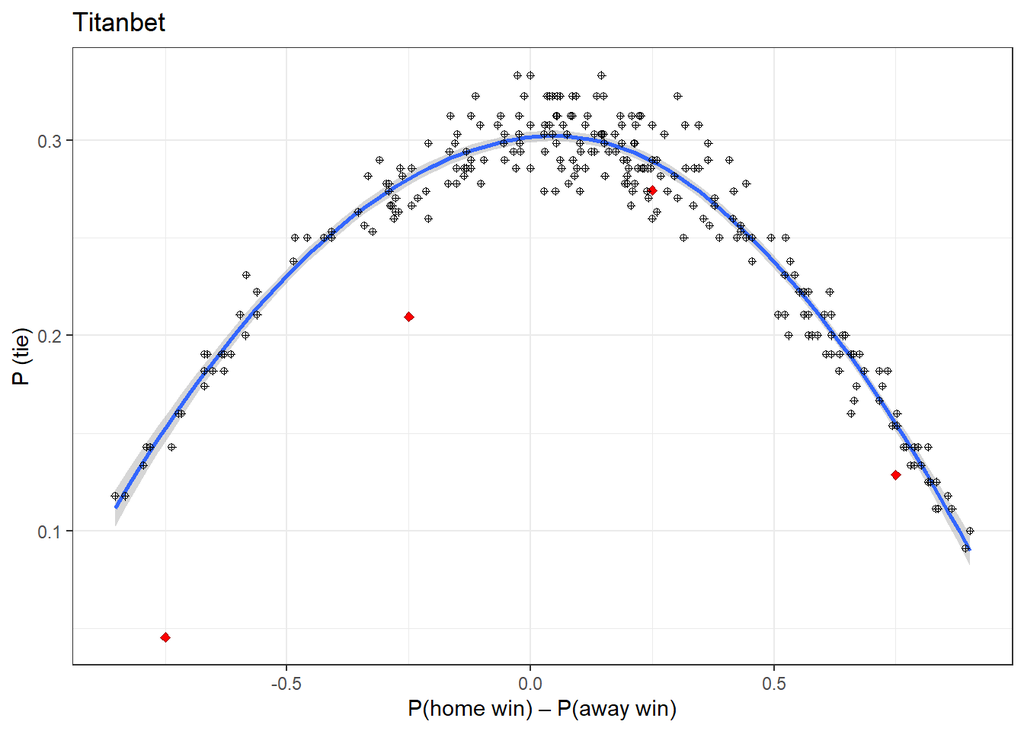

```r
#for actual prob
basic_summ_titan3$interval = ifelse(-1<basic_summ_titan3$diff & basic_summ_titan3$diff< -0.5,-0.75,ifelse(-0.5<basic_summ_titan3$diff & basic_summ_titan3$diff<0,-0.25,ifelse(0<basic_summ_titan3$diff & basic_summ_titan3$diff<0.5,0.25,0.75)))
totaltitan3=basic_summ_titan3 %>%group_by(interval) %>% summarize(n=n())
drawstitan3=basic_summ_titan3 %>% filter(finalstatus == "draw")
totaldrawtitan3=drawstitan3 %>%group_by(interval) %>% summarize(drawcnt=n())
ttltitan3<- left_join(totaltitan3,totaldrawtitan3,by="interval")
ttltitan3= ttltitan3%>%mutate(sampleprb=drawcnt/n)
library(ggplot2)
ggplot(basic_summ_titan3, aes(x = diff, y = odd_x)) +theme_bw() +geom_smooth()+ggtitle("Titanbet")+xlab("P(home win) – P(away win)") + ylab("P (tie)")+
  geom_point(data=ttltitan3,aes(x=interval,y=sampleprb),shape=23, fill="red", color="darkred")+geom_point(data = basic_summ_titan3, aes(x = diff, y = odd_x),shape=10,fill="white", color="black")
```

In both cases, there was no major changes in the graphs due to the deletion of small number of observations. So, similar graphs were obtained.